# Temperatura JP x CG

Julie Pessoa

```r
climas = read_csv(here::here("data/clima_cg_jp-semanal.csv"),
                  col_types = "cTdddddd")

glimpse(climas)
```

```
## Observations: 2,748
## Variables: 8
## $ cidade <chr> "Campina Grande", "Campina Grande", "Campina Grande", "...
## $ semana <dttm> 1992-12-27, 1993-01-03, 1993-01-10, 1993-01-31, 1993-0...
## $ tmedia <dbl> 26.13333, 26.11905, 25.76667, 25.74000, 26.31429, 26.28...
## $ tmax   <dbl> 30.4, 32.4, 32.2, 32.0, 32.7, 32.7, 32.3, 32.3, 32.1, 3...
## $ tmin   <dbl> 20.7, 19.3, 19.7, 19.9, 19.6, 20.0, 20.4, 21.2, 19.0, 1...
## $ chuva  <dbl> 0.0, 0.0, 0.0, 0.4, 0.3, 0.0, 4.9, 0.0, 0.0, 6.1, 0.4, ...
## $ mes    <dbl> 12, 1, 1, 1, 2, 2, 2, 2, 10, 11, 11, 11, 11, 12, 12, 12...
## $ ano    <dbl> 1992, 1993, 1993, 1993, 1993, 1993, 1993, 1993, 1993, 1...
```

## Temperatura

### Onde é mais quente?

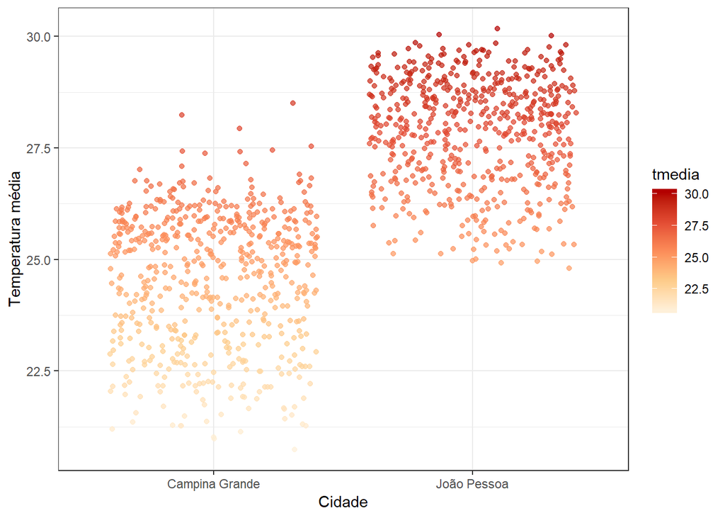

```r
climas %>%
    filter(ano >= 2008) %>%
    ggplot(aes(x = tmedia, y = cidade)) +
    geom_jitter(width = .1, alpha = .7, aes(color = tmedia)) +
    scale_colour_gradientn(colours = brewer.pal(5, "OrRd")) +
    coord_flip() +
    labs(
        x = "Temperatura média",
        y = "Cidade"
    )
```

Analisando a visualização acima, que retrata a temperatura média de Campina Grande e João Pessoa a partir do ano de 2008, é possível observar que as temperaturas de Campina Grande se concetram mais abaixo (mais frio) e as de Joao Pessoa mais acima (mais quente). Portanto é possível deduzir que João Pessoa é a mais quente das cidades. Ainda podemos observar que a dispersão dos pontos para a cidade de Campina Grande é ligeiramente maior do que em João Pessoa, sugerindo que a variação de temperatura em Campina Grande é maior. Eu escolhi a métrica de temperatura média para representação da temperatura para que fosse levado em consideração as extremidades de temperatura também.

### Qual foi o São João mais frio de CG que está nos nossos dados?

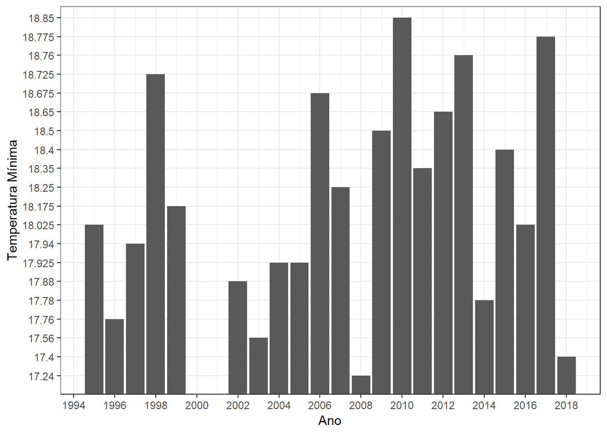

```r
climas %>%
    filter(mes == 6, cidade == "Campina Grande") %>%
    group_by(ano) %>%
    summarise(tmin = mean(tmin)) %>%
    mutate(tmin = factor(tmin))%>%
    ggplot(aes(ano,tmin)) +
    geom_bar(stat="identity") +
    scale_x_continuous(breaks = seq(1994,2019,2)) +
    labs(x = "Ano", y = "Temperatura Mínima")
```

Considerando a média das temperaturas mínimas do mês de Junho de todos os anos coletados, é possível observar na visualização acima que a média das temperaturas em 2008 é a mais baixa em relação as outras. Portanto o São João de 2008 foi o mais frio. É possível observar que o ano de 2000 e 2001 não tem dados coletados no mês de Junho.

## Chuva

### Quanto chove por semana em JP e CG?

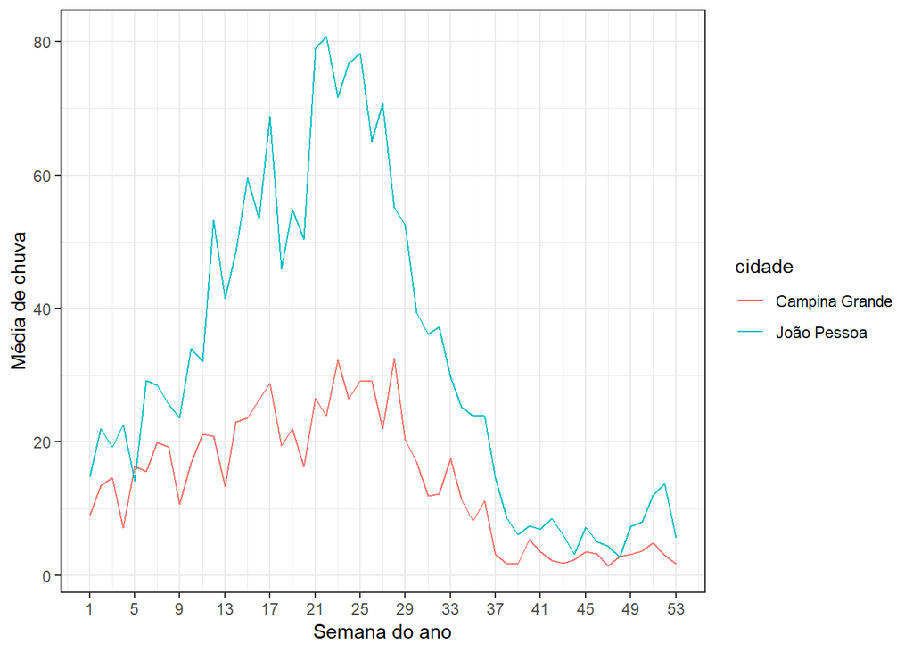

```r
climas %>%
    mutate(semana = as.numeric(strftime(climas$semana, format = "%V"))) %>%
    group_by(semana, cidade) %>%
    summarise(chuva = mean(chuva)) %>%
    ggplot(aes(x=semana,y=chuva, colour=cidade)) +
    geom_line() +
    scale_x_continuous(breaks = seq(1,54,4)) +
    labs(x = "Semana do ano", y = "Média de chuva")
```

### A distribuição é diferente em meses específicos?

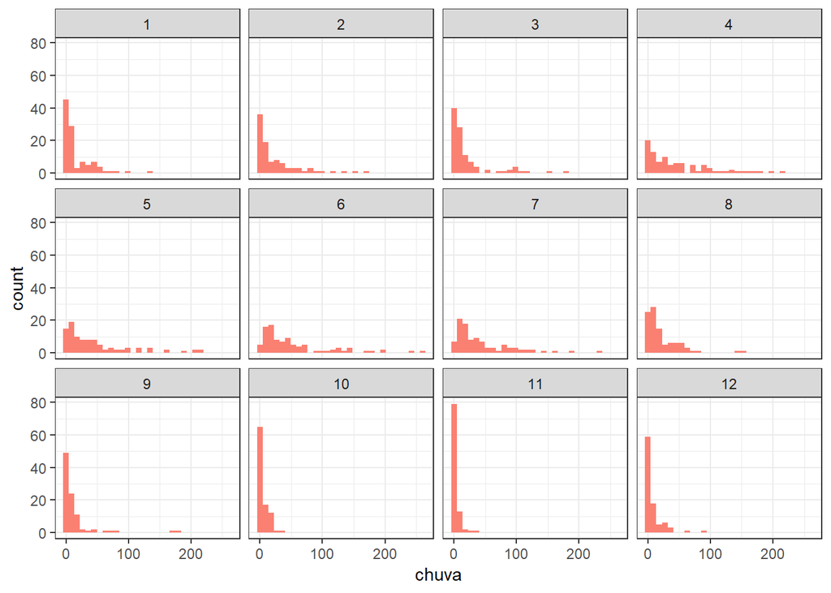

```r
climas %>%
    filter(ano >= 2008) %>%
    ggplot(aes(x = chuva)) +
    geom_histogram(fill = "salmon") +
    facet_wrap(~ mes)
```